# Red Wine Quality Exploration by Tao Zhou

### Description Two

Alcohol is the feature which has the strongest correlation with quality among the features of red wine. They have a positive correlation, athough such a correlation is not very strong. Volatile acidity is the feature which has the second strongest correlation with quality. Volatile acidity and quality have a negative correlation.

### Plot Three: Correlation between fixed acid and density, alcohol and density

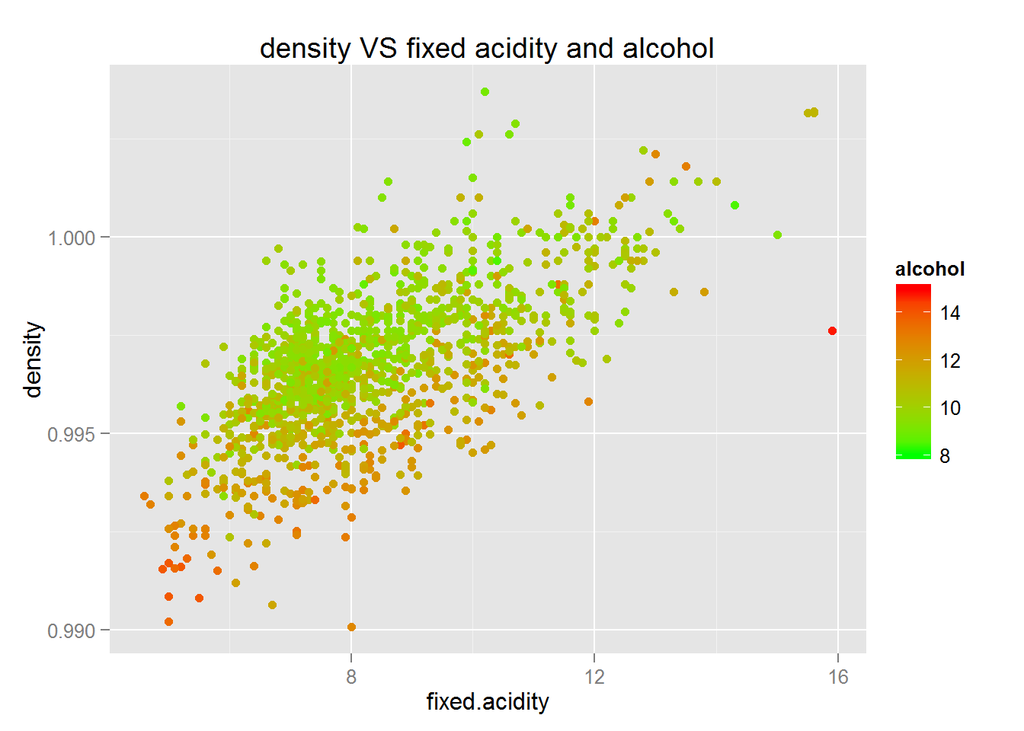

### Description Three

Fixed acidity and alcohol are the two most important features determing wine density. Wine with higher fixed acidity tends to have higher density. And higher alcohol makes the wine density smaller.

# Reflection

The dataset of red wine contains 1599 entries with 12 effective features. When I looked into the data at first glance, I found that the quality is very concentrative. Then I explored each invidual feature and the correlation between these features and quality. Identifying the correlation between one feature and quality is not very easy because it’s usually very weak. Alcohol and volatile acidity are the two most features which have the strongest correlation with quality. Eventually I created a linear model to predict quality. I set the intercept in the model to be 5, since the quality values are very concentrative. I found that by setting the intercept, the model can get R square value larger than 0.98, while R square can only be as large as 0.36 if I did not set the intercept. I also found that with only the two features: alcohol and volatile acidity, the model is already able give me a pretty good predictive result. The limitation of the model is that I have to give it a fixed intercept to make it work. The dataset is not very representative. Although quality levels are from 0 to 10, all the samples’ quality values are between 3 and 8 and most of then focus on 5 and 6.

Except for quality, which is the feature of main interest, I also explored which features may determine the density of wine. I found that fixed acidity and alcohol are the two most important features connecting to wine density. Alcohol has a lighter density while fixed acidity components have a heavier density.